# Modern RD practice, FRD as IV, and CG vs BH (when BH is better)

### 4.1 3.5 Placebo cutoffs, permutation, and donut RD

**What the next three chunks do** - **Placebo cutoffs:** Re-estimate local 2SLS at many fake cutoffs $c^{*} \neq c$; only the true cutoff should “jump”. - **Permutation distribution:** Histogram of placebo estimates from random fake cutoffs; the real estimate should stand out.  
- **Donut RD:** Exclude observations near $c$ and re‑estimate to see if results hinge on the most manipulable region.

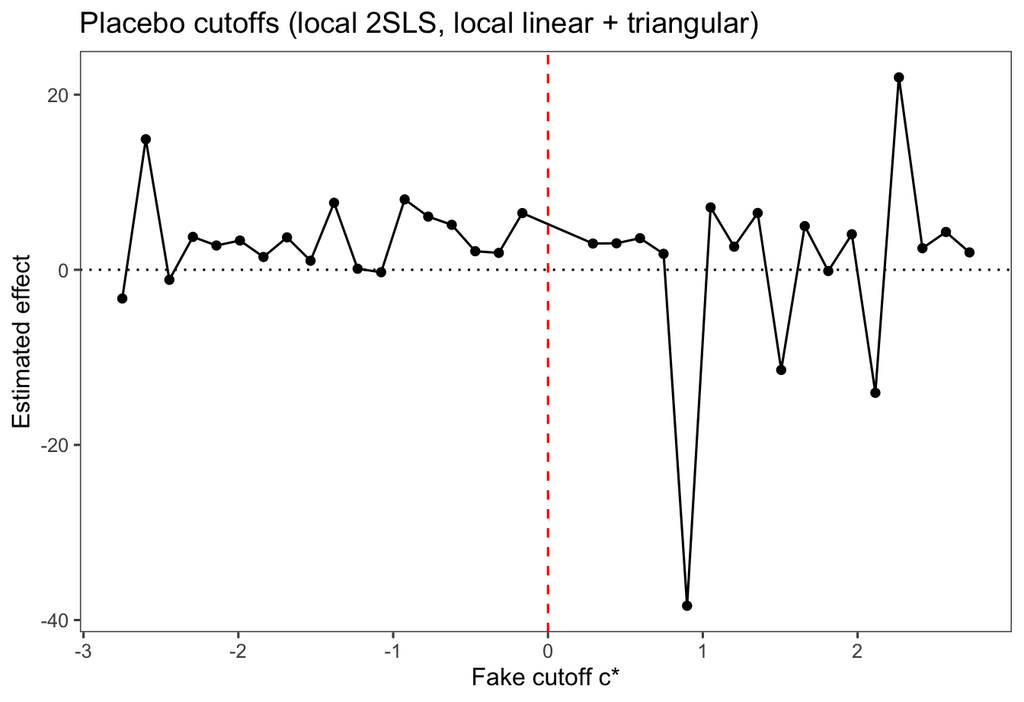

```r
local_iv_at <- function(dat, c, h=0.8){
  loc <- dat %>% filter(abs(x - c) <= h) %>%
    mutate(xc = x - c, right = as.numeric(xc >= 0), T = as.numeric(x >= c), w = pmax(0, 1 - abs(xc)/h))
  if (nrow(loc) < 80) return(tibble(cutoff = c, tau = NA_real_, se = NA_real_))
  fit <- AER::ivreg(y ~ d + xc + right:xc, instruments = ~ T + xc + right:xc, data = loc, weights = w)
  V   <- sandwich::vcovCL(fit, cluster = loc$T)
  tibble(cutoff = c, tau = coef(fit)["d"], se = sqrt(V["d","d"]))
}

grid <- seq(min(frd$x), max(frd$x), length.out = 45)
grid <- grid[abs(grid - c0) > 0.15]  # drop the true cutoff neighborhood
placebos <- purrr::map_dfr(grid, ~ local_iv_at(frd, c = .x, h = 0.8)) %>% tidyr::drop_na()
placebos <- placebos %>% mutate(lo = tau - 1.96*se, hi = tau + 1.96*se)

ggplot(placebos, aes(cutoff, tau)) +
  geom_hline(yintercept = 0, linetype = 3) +
  geom_ribbon(aes(ymin = lo, ymax = hi), alpha = .15) +
  geom_line() + geom_point() +
  geom_vline(xintercept = c0, color = "red", linetype = 2) +
  labs(title = "Placebo cutoffs (local 2SLS, local linear + triangular)", x = "Fake cutoff c*", y = "Estimated effect")
```

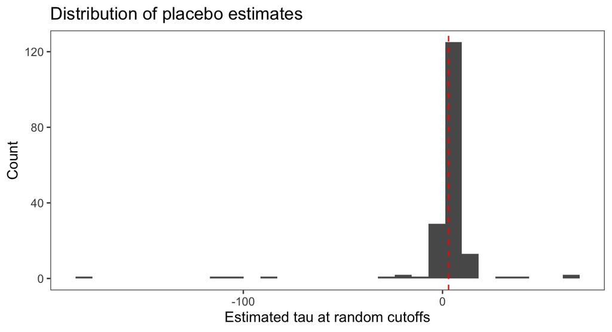

```r
set.seed(123)
rand_c <- runif(200, min(frd$x), max(frd$x))
perm <- purrr::map_dfr(rand_c, ~ local_iv_at(frd, c = .x, h = 0.8)) %>% tidyr::drop_na()
ggplot(perm, aes(tau)) +
  geom_histogram(bins = 30) +
  geom_vline(xintercept = tau_hat, color = "red", linetype = 2) +
  labs(title = "Distribution of placebo estimates", x = "Estimated tau at random cutoffs", y = "Count")
```

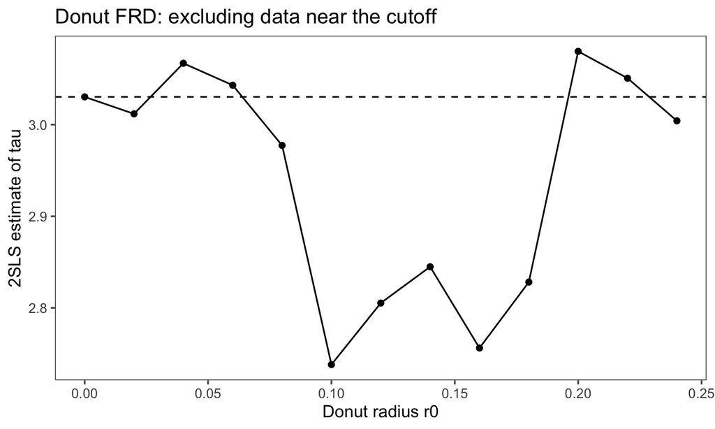

```r
try_r0 <- seq(0, 0.25, by = 0.02)
get_tau_donut <- function(r0){
  loc <- frd %>% filter(abs(x - c0) <= 0.8, abs(x - c0) > r0) %>%
    mutate(xc = x - c0, right = as.numeric(xc >= 0), T = as.numeric(x >= c0), w = pmax(0, 1 - abs(xc)/0.8))
  fit <- AER::ivreg(y ~ d + xc + right:xc, instruments = ~ T + xc + right:xc, data = loc, weights = w)
  coef(fit)["d"]
}
donut <- tibble(r0 = try_r0, tau = purrr::map_dbl(try_r0, get_tau_donut))
ggplot(donut, aes(r0, tau)) + geom_line() + geom_point() +
  geom_hline(yintercept = tau_hat, linetype = 2) +
  labs(title = "Donut FRD: excluding data near the cutoff", x = "Donut radius r0", y = "2SLS estimate of tau")
```

## 5 4) Simulated instruments **with endogenous demographics**

**Why endogeneity?**  
Eligibility $Z_i=f(g_{s(i)}, w_i)$ depends on **policy** $g_s$ and **demographics** $w_i$. If $w_i$ correlates with the outcome error $\varepsilon_i$, then raw eligibility $Z_i$ is **not** a valid IV. We therefore construct **CG** and **BH** instruments that remove the $w$ channel.

### 5.1 4.1 Data‑generating process with **endogenous** demographics

**What this chunk does** - Introduces an unobserved factor $u_i$ that affects **demographics** and the **outcome error**, making $w_i$ endogenous.  
- Constructs states’ policies $g_s$, eligibility $Z_i$, take‑up $X_i$, and outcome $Y_i$.

```r
# States & policies
S <- 40
N <- 500 * S
policy <- tibble(state = 1:S, theta = rnorm(S, mean = 0, sd = 0.6))

# Unobserved factor that drives both demographics and outcome shocks
u <- rnorm(N)

# Endogenous demographics (depend on u)
income <- 0.6*u + rnorm(N)                       # true income
kids   <- rbinom(N, 1, plogis(-0.3 - 0.6*u))     # families with lower u more likely to have kids

# Eligibility rule: eligible if income <= theta_s - 0.4*kids
f_elig <- function(theta, income, kids) as.numeric(income <= theta - 0.4*kids)

# Assemble data
df <- tibble(
  id = 1:N,
  state = rep(1:S, each = N / S),
  theta = policy$theta[match(rep(1:S, each = N / S), policy$state)],
  u = u,
  income = income,
  kids = kids
)

df <- df %>% mutate(
  Z = f_elig(theta, income, kids),                               # raw eligibility (INVALID IV)
  X = rbinom(N, 1, plogis(-0.8 + 1.8*Z + 0.2*income + 0.3*u)),   # take-up: affected by Z and u
  eps = 0.6*u + rnorm(N),                                        # outcome error correlated with u
  beta = 1.2,
  Y = beta*X + 0.4*income + eps                                  # structural outcome
)
```

### 5.2 4.2 Build **CG** and **BH recentered** instruments

**What this chunk does** - Builds $Z^{CG}$ by integrating out demographics using a **fixed national sample** $W^*$.  
- Builds $\tilde z_i = Z_i - \mu_i$ with $\mu_i = \mathbb{E}_g[f(g,w_i)]$ by averaging over the **policy distribution**.

```r
# CG instrument (randomize individuals using a fixed national sample W*)
Wstar <- tibble(income = rnorm(15000, 0, 1), kids = rbinom(15000, 1, 0.5))
cg_by_state <- policy %>%
  rowwise() %>%
  mutate(Z_CG = mean(f_elig(theta, Wstar$income, Wstar$kids))) %>%
  ungroup()
df <- df %>% left_join(cg_by_state %>% select(state, Z_CG), by = "state")

# BH recentered (randomize policies)
mu_i <- sapply(1:nrow(df), function(i){
  mean(f_elig(policy$theta, df$income[i], df$kids[i]))
})
df$z_tilde <- df$Z - mu_i
```

### 5.3 4.3 Sanity check: **Invalid raw Z**, valid CG/BH

**What this chunk does** - Computes correlations with the **true structural error** `eps`.  
- Shows raw `Z` is correlated with the error (invalid), while `Z_CG` and `z_tilde` are not.

```r
with(df, c(
  cor_Z_eps   = cor(Z, eps),
  cor_CG_eps  = cor(Z_CG, eps),
  cor_BH_eps  = cor(z_tilde, eps)
))
```

```
##    cor_Z_eps   cor_CG_eps   cor_BH_eps
## -0.171895623  0.001466527 -0.003038784
```

### 5.4 4.4 First stage (no demographic controls)

**What this chunk does** - Estimates first stages without controlling for demographics (to preserve endogeneity of raw Z).  
- CG varies at **state** level; BH varies **within state** (we include state FE for BH).

```r
fs_rawZ <- lm(X ~ Z, data = df)
fs_cg   <- lm(X ~ Z_CG, data = df)
fs_bh   <- lm(X ~ z_tilde + factor(state), data = df)

modelsummary::msummary(
  list("Raw eligibility Z (invalid IV)" = fs_rawZ,
       "CG simulated IV" = fs_cg,
       "BH recentered IV (+ state FE)" = fs_bh),
  coef_omit = "(^factor\\(state\\)|^\\(Intercept\\)$)",
  gof_omit = "IC|Adj|Within|Pseudo|Log|AIC|BIC",
  statistic = "({std.error})"
)
```

|  | Raw eligibility Z (invalid IV) | CG simulated IV | BH recentered IV (+ state FE) |
| --- | --- | --- | --- |
| Z | 0.280 |  |  |
|  | (0.007) |  |  |
| Z_CG |  | 0.362 |  |
|  |  | (0.019) |  |
| z_tilde |  |  | 0.407 |
|  |  |  | (0.013) |
| Num.Obs. | 20000 | 20000 | 20000 |
| R2 | 0.076 | 0.018 | 0.064 |
| F | 1649.005 | 366.913 | 34.206 |
| RMSE | 0.48 | 0.50 | 0.48 |

### 5.5 4.5 2SLS estimates: **invalid Z** vs **CG/BH**

**What this chunk does** - Compares 2SLS using **raw Z** (invalid), **CG** (valid), and **BH** (valid).  
- Clusters SEs by state; true effect is $beta = 1.2$.

```r
# Naive/invalid IV: uses raw eligibility (endogenous through w)
iv_Z  <- AER::ivreg(Y ~ X | Z, data = df)
V_Z   <- sandwich::vcovCL(iv_Z, cluster = ~ state)

# CG 2SLS: valid (depends only on policy g_s)
iv_CG <- AER::ivreg(Y ~ X | Z_CG, data = df)
V_CG  <- sandwich::vcovCL(iv_CG, cluster = ~ state)

# BH 2SLS: valid (can include state FE because z_tilde varies within state)
iv_BH <- AER::ivreg(Y ~ X + factor(state) | z_tilde + factor(state), data = df)
V_BH  <- sandwich::vcovCL(iv_BH, cluster = ~ state)

lmtest::coeftest(iv_Z,  vcov = V_Z)
```

```
##
## t test of coefficients:
##
##              Estimate Std. Error t value  Pr(>|t|)
## (Intercept)  1.862183   0.081134  22.952 < 2.2e-16 ***
## X           -2.637581   0.162153 -16.266 < 2.2e-16 ***
## ---
## Signif. codes:  0 '***' 0.001 '**' 0.01 '*' 0.05 '.' 0.1 ' ' 1
```

```r
lmtest::coeftest(iv_CG, vcov = V_CG)
```

```
##
## t test of coefficients:
##
##              Estimate Std. Error t value Pr(>|t|)
## (Intercept) -0.009200   0.063661 -0.1445   0.8851
## X            1.213397   0.131962  9.1951   <2e-16 ***
## ---
## Signif. codes:  0 '***' 0.001 '**' 0.01 '*' 0.05 '.' 0.1 ' ' 1
```

```r
lmtest::coeftest(iv_BH, vcov = V_BH)
```

```
##
## t test of coefficients:
##
##                    Estimate  Std. Error     t value  Pr(>|t|)
## (Intercept)     -2.1111e-02  1.0678e-01 -1.9770e-01 0.8432693
## X                1.1523e+00  2.4378e-01  4.7269e+00 2.295e-06 ***
## factor(state)2   5.9215e-02  2.5841e-02  2.2915e+00 0.0219434 *
## factor(state)3  -8.3599e-03  1.1702e-02 -7.1440e-01 0.4749729
## factor(state)4   7.1086e-02  8.7762e-03  8.0999e+00 5.814e-16 ***
## factor(state)5   7.2272e-02  9.7513e-04  7.4115e+01 < 2.2e-16 ***
## factor(state)6  -3.2437e-04  8.2886e-03 -3.9100e-02 0.9687832
## factor(state)7   9.4952e-02  4.3881e-03  2.1639e+01 < 2.2e-16 ***
## factor(state)8   6.4644e-02  8.7762e-03  7.3659e+00 1.829e-13 ***
## factor(state)9   4.9970e-02  1.2189e-02  4.0995e+00 4.156e-05 ***
## factor(state)10  3.2489e-03  2.2428e-02  1.4490e-01 0.8848232
## factor(state)11  3.2135e-02  3.4130e-03  9.4156e+00 < 2.2e-16 ***
## factor(state)12  7.5980e-02  3.6080e-02  2.1059e+00 0.0352269 *
## factor(state)13  5.6903e-02  1.5602e-02  3.6471e+00 0.0002659 ***
## factor(state)14 -7.9060e-03  1.3164e-02 -6.0060e-01 0.5481375
## factor(state)15  6.6404e-02  2.2428e-02  2.9608e+00 0.0030724 **
## factor(state)16  2.3258e-03  1.9990e-02  1.1630e-01 0.9073789
## factor(state)17  1.2601e-01  1.1702e-02  1.0769e+01 < 2.2e-16 ***
## factor(state)18  5.9166e-02  9.7513e-04  6.0675e+01 < 2.2e-16 ***
## factor(state)19 -4.3827e-03  1.0239e-02 -4.2800e-01 0.6686244
## factor(state)20  2.5091e-02  2.4378e-03  1.0292e+01 < 2.2e-16 ***
## factor(state)21  4.4915e-02  1.9990e-02  2.2469e+00 0.0246592 *
## factor(state)22  7.4699e-02  5.8278e-14  1.2818e+12 < 2.2e-16 ***
## factor(state)23  1.0088e-01  7.3135e-03  1.3794e+01 < 2.2e-16 ***
## factor(state)24  5.1787e-02  3.4130e-03  1.5174e+01 < 2.2e-16 ***
## factor(state)25 -3.1717e-02  5.4120e-02 -5.8610e-01 0.5578458
## factor(state)26  4.5021e-02  1.9503e-03  2.3084e+01 < 2.2e-16 ***
## factor(state)27  1.2399e-01  1.6090e-02  7.7064e+00 1.354e-14 ***
## factor(state)28  1.0010e-01  1.3652e-02  7.3320e+00 2.354e-13 ***
## factor(state)29  7.4869e-02  7.8011e-03  9.5973e+00 < 2.2e-16 ***
## factor(state)30  4.6988e-02  1.1214e-02  4.1901e+00 2.800e-05 ***
## factor(state)31  1.0404e-01  4.3881e-02  2.3711e+00 0.0177470 *
## factor(state)32 -6.4140e-02  2.3403e-02 -2.7407e+00 0.0061371 **
## factor(state)33  6.6548e-02  9.7513e-03  6.8246e+00 9.073e-12 ***
## factor(state)34 -1.0006e-01  1.3652e-02 -7.3291e+00 2.405e-13 ***
## factor(state)35 -1.6949e-02  2.3403e-02 -7.2420e-01 0.4689490
## factor(state)36  9.0641e-02  3.7055e-02  2.4461e+00 0.0144488 *
## factor(state)37  5.5255e-02  1.7552e-02  3.1480e+00 0.0016461 **
## factor(state)38  1.1705e-01  3.5592e-02  3.2885e+00 0.0010090 **
## factor(state)39  1.1602e-02  5.0219e-02  2.3100e-01 0.8173023
## factor(state)40 -7.0777e-02  3.9005e-03 -1.8145e+01 < 2.2e-16 ***
## ---
## Signif. codes:  0 '***' 0.001 '**' 0.01 '*' 0.05 '.' 0.1 ' ' 1
```

**What the next chunk does** - Presents all estimates side‑by‑side and shows weak‑IV diagnostics.

```r
modelsummary::modelsummary(
  list("Naive IV with raw Z (invalid)" = iv_Z,
       "CG simulated IV (valid)" = iv_CG,
       "BH recentered IV (valid)" = iv_BH),
  vcov = list(V_Z, V_CG, V_BH),
  coef_map = c("(Intercept)"="Intercept","X"="Treatment (X)"),
  coef_omit = "(^factor\\(state\\)|^\\(Intercept\\)$)",
  gof_omit = "IC|Adj|Within|Pseudo|Log|AIC|BIC"
)
```

|  | Naive IV with raw Z (invalid) | CG simulated IV (valid) | BH recentered IV (valid) |
| --- | --- | --- | --- |
| Treatment (X) | -2.638 | 1.213 | 1.152 |
|  | (0.162) | (0.132) | (0.244) |
| Num.Obs. | 20000 | 20000 | 20000 |
| R2 | -1.484 | 0.156 | 0.157 |
| RMSE | 2.35 | 1.37 | 1.37 |
| Std.Errors | Custom | Custom | Custom |

```r
summary(iv_Z, diagnostics = TRUE)
```

```
##
## Call:
## AER::ivreg(formula = Y ~ X | Z, data = df)
##
## Residuals:
##      Min       1Q   Median       3Q      Max
## -7.16852 -1.90030 -0.08256  1.90904  7.39897
##
## Coefficients:
##             Estimate Std. Error t value Pr(>|t|)
## (Intercept)  1.86218    0.06074   30.66   <2e-16 ***
## X           -2.63758    0.12024  -21.94   <2e-16 ***
##
## Diagnostic tests:
##                    df1   df2 statistic p-value
## Weak instruments     1 19998      1649  <2e-16 ***
## Wu-Hausman           1 19997      3815  <2e-16 ***
## Sargan               0    NA        NA      NA
## ---
## Signif. codes:  0 '***' 0.001 '**' 0.01 '*' 0.05 '.' 0.1 ' ' 1
##
## Residual standard error: 2.346 on 19998 degrees of freedom
## Multiple R-Squared: -1.484,  Adjusted R-squared: -1.484
## Wald test: 481.2 on 1 and 19998 DF,  p-value: < 2.2e-16
```

```r
summary(iv_CG, diagnostics = TRUE)
```

```
##
## Call:
## AER::ivreg(formula = Y ~ X | Z_CG, data = df)
##
## Residuals:
##      Min       1Q   Median       3Q      Max
## -5.29999 -0.92172  0.00313  0.93130  5.49701
##
## Coefficients:
##             Estimate Std. Error t value Pr(>|t|)
## (Intercept)  -0.0092     0.0707  -0.130    0.896
## X             1.2134     0.1441   8.419   <2e-16 ***
##
## Diagnostic tests:
##                    df1   df2 statistic p-value
## Weak instruments     1 19998    366.91  <2e-16 ***
## Wu-Hausman           1 19997      0.07   0.792
## Sargan               0    NA        NA      NA
## ---
## Signif. codes:  0 '***' 0.001 '**' 0.01 '*' 0.05 '.' 0.1 ' ' 1
##
## Residual standard error: 1.367 on 19998 degrees of freedom
## Multiple R-Squared: 0.1557,  Adjusted R-squared: 0.1557
## Wald test: 70.87 on 1 and 19998 DF,  p-value: < 2.2e-16
```

```r
summary(iv_BH, diagnostics = TRUE)
```

```
##
## Call:
## AER::ivreg(formula = Y ~ X + factor(state) | z_tilde + factor(state),
##     data = df)
##
## Residuals:
##        Min         1Q     Median         3Q        Max
## -5.350e+00 -9.186e-01  1.403e-05  9.321e-01  5.450e+00
##
## Coefficients:
##                   Estimate Std. Error t value Pr(>|t|)
## (Intercept)     -0.0211115  0.0732891  -0.288    0.773
## X                1.1523454  0.0921816  12.501   <2e-16 ***
## factor(state)2   0.0592153  0.0870500   0.680    0.496
## factor(state)3  -0.0083599  0.0866129  -0.097    0.923
## factor(state)4   0.0710862  0.0865635   0.821    0.412
## factor(state)5   0.0722722  0.0865006   0.836    0.403
## factor(state)6  -0.0003244  0.0865566  -0.004    0.997
## factor(state)7   0.0949518  0.0865157   1.098    0.272
## factor(state)8   0.0646441  0.0865635   0.747    0.455
## factor(state)9   0.0499699  0.0866225   0.577    0.564
## factor(state)10  0.0032489  0.0869146   0.037    0.970
## factor(state)11  0.0321352  0.0865095   0.371    0.710
## factor(state)12  0.0759800  0.0875691   0.868    0.386
## factor(state)13  0.0569031  0.0867008   0.656    0.512
## factor(state)14 -0.0079060  0.0866429  -0.091    0.927
## factor(state)15  0.0664040  0.0869146   0.764    0.445
## factor(state)16  0.0023258  0.0868295   0.027    0.979
## factor(state)17  0.1260093  0.0866129   1.455    0.146
## factor(state)18  0.0591660  0.0865006   0.684    0.494
## factor(state)19 -0.0043827  0.0865864  -0.051    0.960
## factor(state)20  0.0250908  0.0865047   0.290    0.772
## factor(state)21  0.0449154  0.0868295   0.517    0.605
## factor(state)22  0.0746994  0.0864998   0.864    0.388
## factor(state)23  0.1008847  0.0865440   1.166    0.244
## factor(state)24  0.0517871  0.0865095   0.599    0.549
## factor(state)25 -0.0317171  0.0888876  -0.357    0.721
## factor(state)26  0.0450207  0.0865030   0.520    0.603
## factor(state)27  0.1239942  0.0867135   1.430    0.153
## factor(state)28  0.1000952  0.0866537   1.155    0.248
```

[output cut: 9 more lines]

```
## factor(state)38  0.1170452  0.0875406   1.337    0.181
## factor(state)39  0.0116016  0.0885597   0.131    0.896
## factor(state)40 -0.0707769  0.0865124  -0.818    0.413
##
## Diagnostic tests:
##                    df1   df2 statistic p-value
## Weak instruments     1 19959   939.701  <2e-16 ***
## Wu-Hausman           1 19958     0.071    0.79
## Sargan               0    NA        NA      NA
## ---
## Signif. codes:  0 '***' 0.001 '**' 0.01 '*' 0.05 '.' 0.1 ' ' 1
##
## Residual standard error: 1.368 on 19959 degrees of freedom
## Multiple R-Squared: 0.1571,  Adjusted R-squared: 0.1554
## Wald test: 6.411 on 40 and 19959 DF,  p-value: < 2.2e-16
```

## 6 4B) CG vs BH - When is BH better?

**What this section does**  
- Compares **CG** vs **BH recentered** by varying **policy dispersion** and measuring the **share of infra‑marginal individuals**.  
- Shows BH is typically stronger/more efficient when the infra‑marginal share is high or when including **state FE**.

> **Key ideas to watch in the plots** 1) **Infra‑marginal share** up ⇒ **BH first stage** up relative to CG (CG diluted at state level).  
> 2) **State fixed effects**: BH varies **within** state; CG cannot be used with FE.  
> 3) With many infra‑marginals (low dispersion), BH yields **lower RMSE** for the treatment effect.

```r
sim_once <- function(S=40, N_per=250, sd_theta=0.6, sigma_income=1.0,
                     beta=1.2, u2y=0.6){
  set.seed(NULL)
  # Policies and data
  policy <- tibble(state = 1:S, theta = rnorm(S, 0, sd_theta))
  N <- S * N_per
  u <- rnorm(N)
  income <- 0.6*u + rnorm(N, sd = sigma_income)
  kids <- rbinom(N, 1, plogis(-0.3 - 0.6*u))
  state <- rep(1:S, each = N_per)
  theta_i <- policy$theta[state]
  f_elig <- function(theta, income, kids) as.numeric(income <= theta - 0.4*kids)
  Z <- f_elig(theta_i, income, kids)
  X <- rbinom(N, 1, plogis(-0.8 + 1.8*Z + 0.2*income + 0.3*u))
  eps <- u2y*u + rnorm(N)
  Y <- beta*X + 0.4*income + eps

  # CG instrument (state-level only)
  Wstar <- tibble(income = rnorm(12000, 0, 1),
                  kids   = rbinom(12000, 1, 0.5))
  cg_by_state <- policy %>%
    rowwise() %>%
    mutate(Z_CG = mean(f_elig(theta, Wstar$income, Wstar$kids))) %>%
    ungroup()
  Z_CG <- cg_by_state$Z_CG[state]

  # BH recentered instrument (varies within state)
  mu_i <- sapply(1:length(income), function(i){
    mean(f_elig(policy$theta, income[i], kids[i]))
  })
  z_tilde <- Z - mu_i

  # Share infra-marginal (eligibility invariant across states)
  infra_share <- mean(mu_i %in% c(0,1))

  # First-stage partial F: CG (no FE), BH (+ state FE)
  f_full  <- lm(X ~ Z_CG + income + kids)
  f_rest  <- lm(X ~ income + kids)
  RSS1 <- sum(resid(f_rest)^2); RSS2 <- sum(resid(f_full)^2)
  n <- length(X); p <- 1; k2 <- length(coef(f_full))
  F_CG <- ((RSS1 - RSS2)/p) / (RSS2/(n - k2))

  f_full_bh <- lm(X ~ z_tilde + income + kids + factor(state))
  f_rest_bh <- lm(X ~ income + kids + factor(state))
  RSS1b <- sum(resid(f_rest_bh)^2); RSS2b <- sum(resid(f_full_bh)^2)
  k2b <- length(coef(f_full_bh))
  F_BH <- ((RSS1b - RSS2b)/p) / (RSS2b/(n - k2b))

  # 2SLS
  iv_CG <- AER::ivreg(Y ~ X + income + kids | Z_CG + income + kids)
  iv_BH <- AER::ivreg(Y ~ X + income + kids + factor(state) |
                        z_tilde + income + kids + factor(state))
  bh <- coef(iv_BH)["X"]; cg <- coef(iv_CG)["X"]

  tibble(sd_theta = sd_theta, sigma_income = sigma_income,
         infra_share = infra_share, F_CG = F_CG, F_BH = F_BH,
         err_CG = (cg - beta)^2, err_BH = (bh - beta)^2)
}
```

[figure not shown]

## 7 5) Diagnostics & good practice checklist (with visuals)

**What the next chunk does** - Builds a **placebo covariate** that should be smooth at the cutoff and checks balance using `rdrobust`.  
- Also shows a binscatter balance plot.

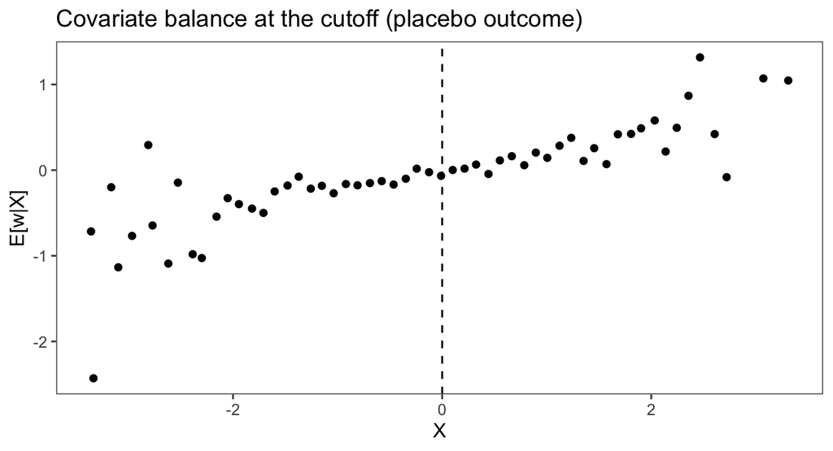

```r
frd$w <- 0.2*frd$x + rnorm(n)
p_bal <- frd %>%
  group_by(bin = cut(x, breaks = seq(min(x), max(x), length.out = 60))) %>%
  summarize(xbar = mean(x), wbar = mean(w), .groups = "drop") %>%
  ggplot(aes(xbar, wbar)) + geom_point() + geom_vline(xintercept = c0, linetype = 2) +
  labs(title = "Covariate balance at the cutoff (placebo outcome)", x = "X", y = "E[w|X]")
print(p_bal)
```

```r
est_bal <- rdrobust(frd$w, frd$x, c = c0, kernel = "triangular", p = 1, q = 2)
summary(est_bal)
```

```
## Sharp RD estimates using local polynomial regression.
##
## Number of Obs.                 4000
## BW type                       mserd
## Kernel                   Triangular
## VCE method                       NN
##
## Number of Obs.                 1998         2002
## Eff. Number of Obs.            1148         1135
## Order est. (p)                    1            1
## Order bias  (q)                   2            2
## BW est. (h)                   0.774        0.774
## BW bias (b)                   1.221        1.221
## rho (h/b)                     0.635        0.635
## Unique Obs.                    1998         2002
##
## =====================================================================
##                    Point    Robust Inference
##                 Estimate         z     P>|z|      [ 95% C.I. ]
## ---------------------------------------------------------------------
##      RD Effect     0.031     0.430     0.667    [-0.162 , 0.254]
## =====================================================================
```

## 8 Appendix: helper utility (local IV, local linear + triangular)

```r
local_iv <- function(dat, c = 0, h = 0.8){
  stopifnot(all(c("y","d","x") %in% names(dat)))
  loc <- dat %>% filter(abs(x - c) <= h) %>%
    mutate(xc = x - c, right = as.numeric(xc >= 0), T = as.numeric(x >= c), w = pmax(0, 1 - abs(xc)/h))
  fit <- AER::ivreg(y ~ d + xc + right:xc, instruments = ~ T + xc + right:xc, data = loc, weights = w)
  fit
}
```